# Assignment 02

Jinghua Mu u7457359

2022-10-31

!(Github repository location)[https://github.com/henflower/Assignment02_meta]

## Part I: Data Processing and Analysis

### 1. Read the study raw data and clean

```r
# install packages
library(pacman)
p_load(tidyverse, flextable, metafor, janitor, ggpmisc, patchwork)
# Install the orchaRd package
## devtools::install_github("daniel1noble/orchaRd", force = TRUE)
library(orchaRd)
```

```r
#read the data of Ckark's research and conceal the index column
current_res <- read_csv("OA_activitydat_20190302_BIOL3207.csv",name_repair = "unique",show_col_types = FALSE) %>%
                     select(-1)
#show context
head(current_res,3)
```

```
## # A tibble: 3 × 8
##   loc       species treatment animal_id    sl size  activity comment
##   <chr>     <chr>   <chr>         <dbl> <dbl> <chr>    <dbl> <chr>
## 1 LIRS 2014 ambon   CO2              64  57.0 big       8.15 27min means of sml…
## 2 LIRS 2014 ambon   CO2              65  38.2 big      10.5  27min means of sml…
## 3 LIRS 2014 ambon   CO2              67  39.3 big       6.51 27min means of sml…
```

```r
# Change some variables to factor to check that the content is correct
current_res <- current_res %>% mutate(loc = as.factor(loc),species = as.factor(species),
                                         size = as.factor(size),treatment = as.factor(treatment))
summary(current_res)
```

```
##         loc           species      treatment     animal_id            sl
##  AIMS 2015: 66   acantho  :196   CO2    :283   Min.   :   1.0   Min.   : 7.50
##  LIRS 2014:195   ambon    : 44   control:306   1st Qu.: 125.0   1st Qu.:11.50
##  LIRS 2016:328   chromis  : 34                 Median : 227.0   Median :24.00
##                  humbug   :142                 Mean   : 281.7   Mean   :26.16
##                  lemon    : 51                 3rd Qu.: 320.0   3rd Qu.:35.25
##                  whitedams:122                 Max.   :9696.0   Max.   :92.53
##                                                NA's   :32
##     size        activity        comment
##  big  :394   Min.   : 1.025   Length:589
##  small:195   1st Qu.:18.622   Class :character
##              Median :27.720   Mode  :character
##              Mean   :28.143
##              3rd Qu.:37.476
##              Max.   :57.573
##              NA's   :7
```

```r
#Check the distribution of NA in the dataset
current_res %>% summarise(across(everything(), ~sum(is.na(.))))
```

```
## # A tibble: 1 × 8
##     loc species treatment animal_id    sl  size activity comment
##   <int>   <int>     <int>     <int> <int> <int>    <int>   <int>
## 1     0       0         0        32     0     0        7       0
```

No spelling errors and particularly unusual values were found, but some values were missing. Because our data is species dependent only, the lack of labels `animal ID` does not affect the availability of the data. So we only removed samples that were missing activities.

```r
#Check whether the number of NA values affects data availability
table(current_res[!complete.cases(current_res$activity),] %>% select(species,loc))
```

```
##            loc
## species     AIMS 2015 LIRS 2014 LIRS 2016
##   acantho           0         2         0
##   ambon             0         1         0
##   chromis           0         0         0
##   humbug            0         2         0
##   lemon             0         2         0
##   whitedams         0         0         0
```

```r
#Remove missing values
current_res <- current_res[complete.cases(current_res$activity),]
```

### 2. Generate statistics and merge files

```r
# the path of metadata file to append new infomation
append_path = "ocean_meta_data.csv"
existing_res <- read_csv(append_path,show_col_types = FALSE)
# Get the amount of information we need
glimpse(existing_res)
```

```
## Rows: 824
## Columns: 22
## $ Study                <chr> "a1", "a1", "a1", "a1", "a1", "a1", "a1", "a2", "…
## $ Authors              <chr> "Munday et al", "Munday et al", "Munday et al", "…
## $ `Year (online)`      <dbl> 2009, 2009, 2009, 2009, 2009, 2009, 2009, 2009, 2…
## $ `Year (print)`       <dbl> 2009, 2009, 2009, 2009, 2009, 2009, 2009, 2010, 2…
## $ Title                <chr> "Ocean acidification impairs olfactory discrimina…
## $ Journal              <chr> "PNAS", "PNAS", "PNAS", "PNAS", "PNAS", "PNAS", "…
## $ `Pub year IF`        <chr> "9.432", "9.432", "9.432", "9.432", "9.432", "9.4…
## $ `2017 IF`            <chr> "9.504", "9.504", "9.504", "9.504", "9.504", "9.5…
## $ `Average n`          <dbl> 27, 27, 27, 27, 27, 27, 27, 15, 15, 15, 15, 15, 1…
## $ `Effect type`        <chr> "Strong", "Strong", "Strong", "Strong", "Strong",…
## $ Species              <chr> "Amphiprion percula", "Amphiprion percula", "Amph…
## $ `Climate (FishBase)` <chr> "Trop", "Trop", "Trop", "Trop", "Trop", "Trop", "…
## $ `Env cue/stimulus?`  <chr> "Yes", "Yes", "Yes", "Yes", "Yes", "Yes", "Yes", …
## $ `Cue/stimulus type`  <chr> "Habitat", "Habitat", "Habitat", "Habitat", "Kin"…
## $ `Behavioural metric` <chr> "% time in Xanthostemon cue", "% time in Melaleuc…
## $ `Life stage`         <chr> "Larvae", "Larvae", "Larvae", "Larvae", "Larvae",…
## $ ctrl.n               <dbl> 26, 20, 20, 10, 30, 30, 30, 45, 45, 45, 45, 45, 4…
## $ ctrl.mean            <dbl> 94.1290, 0.7830, 46.3800, 98.8260, 0.9120, 90.876…
## $ ctrl.sd              <dbl> 2.9931, 3.5017, 14.0023, 1.8563, 2.9960, 3.9984, …
## $ oa.n                 <dbl> 46, 46, 46, 16, 20, 20, 20, 45, 45, 45, 45, 45, 4…
## $ oa.mean              <dbl> 72.7890, 83.5620, 71.4290, 88.2580, 99.8180, 99.8…
## $ oa.sd                <dbl> 13.2730, 10.6211, 13.2730, 7.0440, 0.0045, 0.0045…
```

```r
# Modify our treatment names to match the reference documentation
levels(current_res$treatment)[levels(current_res$treatment)=="control"] <- "ctrl"
levels(current_res$treatment)[levels(current_res$treatment)=="CO2"] <- "oa"
# calculate mean,SD and N of activity across each species and treatment
current_sta <- current_res %>% group_by(treatment,species) %>% summarise(mean = mean(activity),sd = sd(activity),n = n(),.groups = "drop") %>%
       pivot_wider(names_from = treatment,names_glue = "{treatment}.{.value}",values_from = c(mean,n,sd))
```

```r
# the path of supplemental information about clark's research
current_info <- read_csv("clark_paper_data.csv",show_col_types = FALSE)
# using cbind() to extend supplemental information to each experimental group
append_info <- cbind(tibble(current_info),current_sta)
# colnames(append_info)
#Fix problem with the order and partial naming of columns was found
append_info <- append_info %>%rename(Species = species) %>% select(colnames(existing_res))
```

```r
# write_lines("",file = append_path,append = TRUE)
# write_csv(append_info, file = append_path, append = TRUE,col_names = FALSE)
rm(list = ls())
```

### 3. Generate lnRR and sampling variance

In the previous section we found a problem with data reading for metadata, some numeric variables are read in character format, and we want to check the non-numeric content of these variables and correct all the variables into suitable format.

```r
# Use *janitor* to fix column names for easy selection
meta_data <- read_csv("ocean_meta_data.csv",show_col_types = FALSE) %>% janitor::clean_names()
ini_size = nrow(meta_data)
# Some numeric variables are read in chr type, cheack the non-numeric element
unique(meta_data$pub_year_if[is.na(as.numeric(meta_data$pub_year_if))])
```

```
## [1] "-"
```

```r
unique(meta_data$x2017_if[is.na(as.numeric(meta_data$x2017_if))])
```

```
## [1] "-"
```

```r
#Correct "-" to NA by forced type conversion. Correct some variables to factor type
meta_data[meta_data == "-"] <- NA
meta_data$cue_stimulus_type[is.na(meta_data$cue_stimulus_type)] <- "None"
meta_data <- meta_data %>% mutate(pub_year_if = as.numeric(pub_year_if), x2017_if = as.numeric(x2017_if),
                        effect_type = as.factor(effect_type), climate_fish_base = as.factor(climate_fish_base),
                        env_cue_stimulus = as.factor(env_cue_stimulus), cue_stimulus_type = as.factor(cue_stimulus_type),
                        species = as.factor(species))
# Check the dataset again
summary(meta_data)
```

```
##     study             authors           year_online     year_print
##  Length:824         Length:824         Min.   :2009   Min.   :2009
##  Class :character   Class :character   1st Qu.:2012   1st Qu.:2013
##  Mode  :character   Mode  :character   Median :2015   Median :2015
##                                        Mean   :2015   Mean   :2015
##                                        3rd Qu.:2017   3rd Qu.:2018
##                                        Max.   :2020   Max.   :2020
##
##     title             journal           pub_year_if        x2017_if
##  Length:824         Length:824         Min.   : 0.839   Min.   : 0.794
##  Class :character   Class :character   1st Qu.: 2.504   1st Qu.: 2.504
##  Mode  :character   Mode  :character   Median : 3.730   Median : 3.345
##                                        Mean   : 5.909   Mean   : 5.867
##                                        3rd Qu.: 8.044   3rd Qu.: 8.997
##                                        Max.   :69.500   Max.   :41.580
##                                        NA's   :24       NA's   :15
##    average_n      effect_type                     species
##  Min.   :  4.00   No    :236   Pomacentrus amboinensis:114
##  1st Qu.: 12.00   Strong:474   Amphiprion percula     : 80
##  Median : 17.00   Weak  :114   Gasterosteus aculeatus : 48
##  Mean   : 28.69                Citharichthys stigmaeus: 40
##  3rd Qu.: 30.00                Gadus macrocephalus    : 36
##  Max.   :568.00                Pomacentrus wardi      : 35
##                                (Other)                :471
##     climate_fish_base env_cue_stimulus cue_stimulus_type behavioural_metric
##  Boreal      : 36     No :171          Predator:180      Length:824
##  Deep        :  2     Yes:653          None    :175      Class :character
##  Not provided:  7                      Food    :105      Mode  :character
##  Polar       : 26                      Shelter : 58
##  Subtrop     :221                      Habitat : 56
##  Temp        : 86                      Light   : 44
##  Trop        :446                      (Other) :206
##   life_stage            ctrl_n         ctrl_mean            ctrl_sd
##  Length:824         Min.   :  4.00   Min.   :   -69.78   Min.   :    0.000
##  Class :character   1st Qu.: 10.00   1st Qu.:     1.08   1st Qu.:    1.176
##  Mode  :character   Median : 18.00   Median :     9.52   Median :    5.867
##                     Mean   : 29.14   Mean   :   435.63   Mean   :  103.754
##                     3rd Qu.: 30.00   3rd Qu.:    43.11   3rd Qu.:   21.524
##                     Max.   :752.00   Max.   :154936.88   Max.   :25490.446
##
##       oa_n           oa_mean              oa_sd
##  Min.   :  2.00   Min.   :   -59.67   Min.   :    0.00
##  1st Qu.: 11.00   1st Qu.:     1.21   1st Qu.:    1.17
##  Median : 18.00   Median :    12.37   Median :    7.26
##  Mean   : 29.04   Mean   :   435.35   Mean   :  113.65
##  3rd Qu.: 34.00   3rd Qu.:    43.32   3rd Qu.:   22.05
##  Max.   :755.00   Max.   :157061.25   Max.   :36812.37
##
```

The mean values of both groups were found to vary greatly between experiments. We made an attempt to convert them to Log response ratio (lnRR).

```r
meta_RR <- metafor::escalc(measure = "ROM", data = meta_data,m1i = oa_mean, m2i = ctrl_mean,
      sd1i = oa_sd, sd2i = ctrl_sd,n1i = oa_n, n2i = ctrl_n,var.names = c("lnRR", "VRR"))
```

The reason for getting NA is that $lnRR = ln\frac{\bar{X_1}}{\bar{X_2}}$, which cannot be calculated when the signs of the two response variables do not agree. We believe that the reason for the inconsistency in the sign of the two variables is that: part of the experiments screened by metadata is to measure the change from particular baseline for each treatment.

```r
# Most of NA has *change/rate* in behavioural_metric
meta_RR[!complete.cases(meta_RR$lnRR),] %>% select(study,behavioural_metric, ctrl_mean,oa_mean,lnRR)
```

```
##
##     study                                         behavioural_metric ctrl_mean
## 89     a6                           Prop change in response, 850 ppm     0.408
## 91     a6                           Prop change in response, 850 ppm     0.501
## 93     a6                           Prop change in response, 850 ppm     0.426
## 121   a11 Change in feeding strikes, true conditioning, water, Fig 1     3.009
## 127   a11      Change in area use, pseudo-conditioning, water, Fig 1     0.179
## 128   a11   Change in area use, pseudo-conditioning, predator, Fig 1    -0.441
## 129   a11        Change in area use, true conditioning, water, Fig 1    -0.069
## 130   a11     Change in area use, true conditioning, predator, Fig 1    -2.687
## 137   a11    Change in line crosses, experienced tutor, water, Fig 2    -2.250
## 141   a11        Change in area use, experienced tutor, water, Fig 2     0.195
## 142   a11     Change in area use, experienced tutor, predator, Fig 2    -1.995
## 155   a11                           Change in area use, water, Fig 4    -0.076
## 223   a22                     Mean change bite rate, empty bag, Fig2     1.005
```

[output cut: 34 more lines]

We further counted the keyword occurrences of the study in which the NA experiments were found. The results showed that 104 of the 109 experiments had keywords with **change** and **rate**. We believe that such experiments do not show their effect sizes correctly by response ratio ($lnRR = ln\frac{\bar{X_1}-M}{\bar{X_2}-M} \neq \frac{\bar{X_1}}{\bar{X_2}}$).

```r
# get all the study id of NA values
doubtful_study <- unique(meta_RR[!complete.cases(meta_RR$lnRR),]$study)
# number of experiments matched keyword in doubtful study
num_match <- meta_data %>% filter(study %in% doubtful_study) %>%
         filter(grepl("change|Change|rate|Rate",behavioural_metric)) %>% nrow()
# number of experiments of all study including NA value
num_in_study <- meta_data %>% filter(study %in% doubtful_study) %>% nrow()
print(paste("Num of rows matching keywords:",num_match,",Num of experiments:",num_in_study))
```

```
## [1] "Num of rows matching keywords: 104 ,Num of experiments: 109"
```

Therefore, we chose to **label** the experiments in these studies and all other experiments with the keyword **“change”** to detect the effect size bias between these and other experiments. Also, we removed those experiments where lnRR was NA.

```r
# Remove NA and mark  experiment with change or in "doubtful study"
meta_RR <- meta_RR %>%  filter(!is.na(lnRR)) %>%
         mutate(measure_change = (study %in% doubtful_study)|grepl("change|Change",behavioural_metric) )
```

We test whether the obtained lnRR and its variance VRR have a appropriate distribution and size.

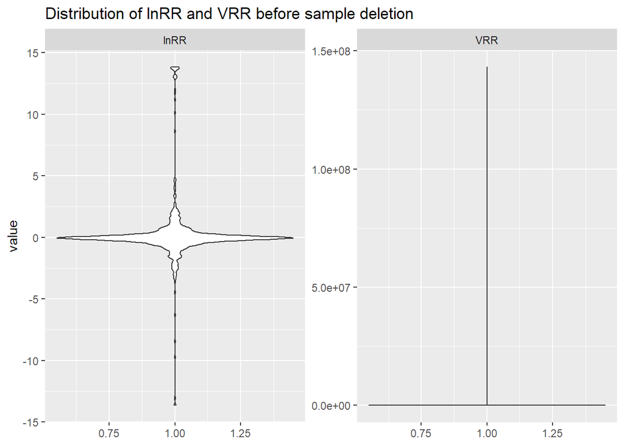

Figure 1: Distribution of lnRR and VRR before sample deletion

```r
# plot distribution of lnRR and VRR
meta_RR %>% select(lnRR, VRR) %>% pivot_longer(cols = lnRR:VRR, names_to = "type", values_to = "value") %>%
      ggplot(aes(x = 1,y = value)) + geom_violin() + facet_wrap(~type, scale = "free") + ggtitle("Distribution of lnRR and VRR before sample deletion") + xlab(NULL)
```

The violin plot 1 shows that the shape of lnRR is consistent with its normally distributed nature, but the values at both ends are large, and the extreme values of the response ratio reach the level of $e^{14}$, which is unimaginable but we cannot deny its plausibility. However, the shape of the VRR is extremely anomalous, and there are individual extremely large VRRs. we consider the results of experiments with too large variance relative to the effect values to be unreliable, and we therefore choose to remove these experiments.  
To prevent bias, we used $ (sd(lnRR) > 2|lnRR|) (sd(lnRR) > ln(1.5))$ as a criterion.